# Processo Seletivo 4intelligence

Hugo Lima de Oliveira

2022-09-26

## R Markdown

Definição do diretório de trabalho e importação das bibliotecas

```r
setwd('C:\\Users\\Hugol\\Downloads\\4intelligence')
library(readxl)
```

```r
library(ggplot2)
library(dplyr)
library(tidyverse)
library(ggthemes)
library(sidrar)
library(xtable)
```

```r
#leitura da base
#extração do nome das planilhas
sheet_names <- excel_sheets("dados_desafiodatascientistintern_vendas_distribuidoras_anp.xlsx")
sheet_names
```

```
## [1] "diesel"   "gasolina" "etanol"
```

```r
#função que cria dataframe para cada planilha
list_all <- lapply(sheet_names, function(x) {
  as.data.frame(read_excel("dados_desafiodatascientistintern_vendas_distribuidoras_anp.xlsx", sheet = x)) } )

names(list_all) <- sheet_names
#organização das colunas para cada dataframe
diesel=list_all$diesel %>%
  gather('ano','diesel',3:23) %>%
  rename(mes=meses,
         cd_uf=regiao)
gasolina=list_all$gasolina %>%
  gather('ano','gasolina',3:23) %>%
  rename(mes=meses,
         cd_uf=regiao)
etanol=list_all$etanol %>%
  gather('ano','etanol',3:23) %>%
  rename(mes=meses,
         cd_uf=regiao)
xtable(diesel)
```

| cd_uf | mes | ano | diesel |
| --- | --- | --- | --- |
| df | 1 | 2000 | 23310.90 |
| df | 2 | 2000 | 25967.74 |
| df | 3 | 2000 | 24590.67 |
| df | 4 | 2000 | 24975.96 |
| df | 5 | 2000 | 27224.60 |
| df | 6 | 2000 | 27931.62 |
| df | 7 | 2000 | 28778.73 |
| df | 8 | 2000 | 34207.58 |
| df | 9 | 2000 | 31098.80 |
| df | 10 | 2000 | 32876.87 |

[output cut: 2258 more lines]

```r
xtable(gasolina)
```

| cd_uf | mes | ano | gasolina |
| --- | --- | --- | --- |
| df | 1 | 2000 | 39257.909 |
| df | 2 | 2000 | 49569.772 |
| df | 3 | 2000 | 48423.406 |
| df | 4 | 2000 | 48553.004 |
| df | 5 | 2000 | 51085.485 |
| df | 6 | 2000 | 53138.994 |
| df | 7 | 2000 | 47297.271 |
| df | 8 | 2000 | 51706.871 |
| df | 9 | 2000 | 49501.962 |
| df | 10 | 2000 | 52617.237 |

[output cut: 2258 more lines]

```r
xtable(etanol)
```

| cd_uf | mes | ano | etanol |
| --- | --- | --- | --- |
| df | 1 | 2000 | 11687.9300 |
| df | 2 | 2000 | 13407.9930 |
| df | 3 | 2000 | 13389.1840 |
| df | 4 | 2000 | 12680.9550 |
| df | 5 | 2000 | 13046.8140 |
| df | 6 | 2000 | 10143.6160 |
| df | 7 | 2000 | 12937.6150 |
| df | 8 | 2000 | 12318.1680 |
| df | 9 | 2000 | 11602.6180 |
| df | 10 | 2000 | 11976.3540 |

[output cut: 2258 more lines]

Unificação das bases de cada combustível

```r
#definição de parâmetros
trim1=c(1,2,3)
trim2=c(4,5,6)
trim3=c(7,8,9)
sem1=c(1,2,3,4,5,6)
anos=c(2000:2020)
#unificação das bases
df=diesel %>%
  full_join(gasolina,by=c('cd_uf','ano','mes')) %>%
  full_join(etanol,by=c('cd_uf','ano','mes')) %>%
  mutate(trimestre=ifelse(mes %in% trim1,1,
                          ifelse(mes %in% trim2,2,
                                 ifelse(mes %in% trim3,3,4))),
         semestre=ifelse(mes %in% sem1,1,2))
#base anual
df_anual=df %>% group_by(ano,cd_uf) %>%
  summarise(gasolina=mean(gasolina),
            etanol=mean(etanol),
            diesel=mean(diesel)) %>%
  mutate(min_diesel=min(diesel),
         max_diesel=max(diesel),
         min_etanol=min(etanol),
         max_etanol=max(etanol),
         min_gasolina=min(gasolina),
         max_gasolina=max(gasolina))
```

[output not shown]

```r
#base trimestral
df_trimestral=df %>% group_by(trimestre,cd_uf) %>%
  summarise(gasolina=mean(gasolina),
            etanol=mean(etanol),
            diesel=mean(diesel)) %>%
  mutate(min_diesel=min(diesel),
         max_diesel=max(diesel),
         min_etanol=min(etanol),
         max_etanol=max(etanol),
         min_gasolina=min(gasolina),
         max_gasolina=max(gasolina))
#base mensal
df_mensal=df %>% group_by(mes,cd_uf) %>%
  summarise(gasolina=mean(gasolina),
            etanol=mean(etanol),
            diesel=mean(diesel)) %>%
  mutate(min_diesel=min(diesel),
         max_diesel=max(diesel),
         min_etanol=min(etanol),
         max_etanol=max(etanol),
         min_gasolina=min(gasolina),
         max_gasolina=max(gasolina))
```

[output not shown]

```r
#base semestral
df_semestral=df %>% group_by(semestre,cd_uf) %>%
  summarise(gasolina=mean(gasolina),
            etanol=mean(etanol),
            diesel=mean(diesel)) %>%
  mutate(min_diesel=min(diesel),
         max_diesel=max(diesel),
         min_etanol=min(etanol),
         max_etanol=max(etanol),
         min_gasolina=min(gasolina),
         max_gasolina=max(gasolina))
xtable(df)
```

| cd_uf | mes | ano | diesel | gasolina | etanol | trimestre | semestre |
| --- | --- | --- | --- | --- | --- | --- | --- |
| df | 1 | 2000 | 23310.90 | 39257.909 | 11687.9300 | 1 | 1 |
| df | 2 | 2000 | 25967.74 | 49569.772 | 13407.9930 | 1 | 1 |
| df | 3 | 2000 | 24590.67 | 48423.406 | 13389.1840 | 1 | 1 |
| df | 4 | 2000 | 24975.96 | 48553.004 | 12680.9550 | 2 | 1 |
| df | 5 | 2000 | 27224.60 | 51085.485 | 13046.8140 | 2 | 1 |
| df | 6 | 2000 | 27931.62 | 53138.994 | 10143.6160 | 2 | 1 |
| df | 7 | 2000 | 28778.73 | 47297.271 | 12937.6150 | 3 | 2 |
| df | 8 | 2000 | 34207.58 | 51706.871 | 12318.1680 | 3 | 2 |
| df | 9 | 2000 | 31098.80 | 49501.962 | 11602.6180 | 3 | 2 |
| df | 10 | 2000 | 32876.87 | 52617.237 | 11976.3540 | 4 | 2 |

[output cut: 2258 more lines]

Importação da base do IPCA (número índice de janeiro 2001 até agosto de 2022) para fazer a deflação dos preços dos combustíveis

```r
#ipca
ipca=read.csv2('ipca.csv') %>%
  mutate(n_indice=as.numeric(n_indice),
         ano=as.numeric(ano))
xtable(ipca)
```

| ano | mes | n_indice |
| --- | --- | --- |
| 2001 | 1 | 0.2650030 |
| 2001 | 2 | 0.2662224 |
| 2001 | 3 | 0.2672335 |
| 2001 | 4 | 0.2687831 |
| 2001 | 5 | 0.2698850 |
| 2001 | 6 | 0.2712890 |
| 2001 | 7 | 0.2748968 |
| 2001 | 8 | 0.2768205 |
| 2001 | 9 | 0.2775953 |
| 2001 | 10 | 0.2798993 |

[output cut: 250 more lines]

Definição dos parâmetros

```r
ufs=c('DISTRITO FEDERAL','MINAS GERAIS','SAO PAULO','TOCANTINS','GOIAS','MATO GROSSO','MARANHAO','PARA')
combustiveis=c('ETANOL HIDRATADO','GASOLINA COMUM','OLEO DIESEL')
```

Importação da base de preços médios dos combustíveis por ano e mês

```r
#base de 2001 a 2012
anp_2001_2012=read_excel('precos_anp_2001_2012.xlsx') %>%
  select(mes,uf,unidade_medida,preco_medio_revenda,combustivel)
#base de 2013 a 2022
anp_2013_2022=read_excel('precos_anp_2013_2022.xlsx')  %>%
  select(mes,uf,unidade_medida,preco_medio_revenda,combustivel)
#união das duas bases
anp_precos=anp_2001_2012 %>% union(anp_2013_2022) %>%
  mutate(ano=substr(mes,1,4),                      #definição das variáveis temporais
         mes=substr(mes,6,7),
         mes=as.numeric(mes),
         ano=as.numeric(ano)) %>%
  subset((uf %in% ufs) & (combustivel %in% combustiveis)) %>% #filtro para ufs e combustiveis
  spread(combustivel,preco_medio_revenda) %>%
  rename(gasolina_preco_revenda_l=`GASOLINA COMUM`,
         etanol_preco_revenda_l=`ETANOL HIDRATADO`,
         diesel_preco_revenda_l= `OLEO DIESEL`) %>%
  mutate(gasolina_preco_revenda_m3=gasolina_preco_revenda_l*1000, #preços por m3
         etanol_preco_revenda_m3=etanol_preco_revenda_l*1000,
         diesel_preco_revenda_m3=diesel_preco_revenda_l*1000)
xtable(anp_precos)
```

| mes | uf | unidade_medida | ano | etanol_preco_revenda_l | gasolina_preco_revenda_l | diesel_preco_revenda_l | gasolina_preco_revenda_m3 | etanol_preco_revenda_m3 | diesel_preco_revenda_m3 |
| --- | --- | --- | --- | --- | --- | --- | --- | --- | --- |
| 1 | DISTRITO FEDERAL | R$/l | 2002 | 1.1746 | 1.5720 | NA | 1572.0 | 1174.6 | NA |
| 1 | DISTRITO FEDERAL | R$/l | 2003 | 1.6378 | 2.1699 | NA | 2169.9 | 1637.8 | NA |
| 1 | DISTRITO FEDERAL | R$/l | 2004 | 1.4735 | 2.0447 | NA | 2044.7 | 1473.5 | NA |
| 1 | DISTRITO FEDERAL | R$/l | 2005 | 1.6800 | 2.2090 | NA | 2209.0 | 1680.0 | NA |
| 1 | DISTRITO FEDERAL | R$/l | 2006 | 1.9070 | 2.6090 | NA | 2609.0 | 1907.0 | NA |
| 1 | DISTRITO FEDERAL | R$/l | 2007 | 1.8070 | 2.5360 | NA | 2536.0 | 1807.0 | NA |
| 1 | DISTRITO FEDERAL | R$/l | 2008 | 1.8610 | 2.5920 | NA | 2592.0 | 1861.0 | NA |
| 1 | DISTRITO FEDERAL | R$/l | 2009 | 1.8800 | 2.6760 | NA | 2676.0 | 1880.0 | NA |
| 1 | DISTRITO FEDERAL | R$/l | 2010 | 2.1440 | 2.7440 | NA | 2744.0 | 2144.0 | NA |
| 1 | DISTRITO FEDERAL | R$/l | 2011 | 2.0600 | 2.7740 | NA | 2774.0 | 2060.0 | NA |

[output cut: 2014 more lines]

Deflação dos preços

```r
anp_precos_reais=anp_precos %>% full_join(ipca, by=c('ano','mes')) %>%
  mutate(gasolina_preco_real_l=gasolina_preco_revenda_l*n_indice,
         etanol_preco_real_l=etanol_preco_revenda_l*n_indice,
         diesel_preco_real_l=diesel_preco_revenda_l*n_indice,
         gasolina_preco_real_m3=gasolina_preco_revenda_m3*n_indice,
         etanol_preco_real_m3=etanol_preco_revenda_m3*n_indice,
         diesel_preco_real_m3=diesel_preco_revenda_m3*n_indice)
xtable(anp_precos_reais)
```

| mes | uf | unidade_medida | ano | etanol_preco_revenda_l | gasolina_preco_revenda_l | diesel_preco_revenda_l | gasolina_preco_revenda_m3 | etanol_preco_revenda_m3 | diesel_preco_revenda_m3 | n_indice | gasolina_preco_real_l | etanol_preco_real_l | diesel_preco_real_l | gasolina_preco_real_m3 | etanol_preco_real_m3 | diesel_preco_real_m3 |
| --- | --- | --- | --- | --- | --- | --- | --- | --- | --- | --- | --- | --- | --- | --- | --- | --- |
| 1 | DISTRITO FEDERAL | R$/l | 2002 | 1.1746 | 1.5720 | NA | 1572.0 | 1174.6 | NA | 0.2851960 | 0.4483281 | 0.3349912 | NA | 448.3281 | 334.9912 | NA |
| 1 | DISTRITO FEDERAL | R$/l | 2003 | 1.6378 | 2.1699 | NA | 2169.9 | 1637.8 | NA | 0.3264552 | 0.7083752 | 0.5346684 | NA | 708.3752 | 534.6684 | NA |
| 1 | DISTRITO FEDERAL | R$/l | 2004 | 1.4735 | 2.0447 | NA | 2044.7 | 1473.5 | NA | 0.3516162 | 0.7189496 | 0.5181064 | NA | 718.9496 | 518.1064 | NA |
| 1 | DISTRITO FEDERAL | R$/l | 2005 | 1.6800 | 2.2090 | NA | 2209.0 | 1680.0 | NA | 0.3776615 | 0.8342542 | 0.6344713 | NA | 834.2542 | 634.4713 | NA |
| 1 | DISTRITO FEDERAL | R$/l | 2006 | 1.9070 | 2.6090 | NA | 2609.0 | 1907.0 | NA | 0.3991880 | 1.0414814 | 0.7612514 | NA | 1041.4814 | 761.2514 | NA |
| 1 | DISTRITO FEDERAL | R$/l | 2007 | 1.8070 | 2.5360 | NA | 2536.0 | 1807.0 | NA | 0.4111150 | 1.0425875 | 0.7428847 | NA | 1042.5875 | 742.8847 | NA |
| 1 | DISTRITO FEDERAL | R$/l | 2008 | 1.8610 | 2.5920 | NA | 2592.0 | 1861.0 | NA | 0.4298679 | 1.1142175 | 0.7999841 | NA | 1114.2175 | 799.9841 | NA |
| 1 | DISTRITO FEDERAL | R$/l | 2009 | 1.8800 | 2.6760 | NA | 2676.0 | 1880.0 | NA | 0.4549693 | 1.2174980 | 0.8553424 | NA | 1217.4980 | 855.3424 | NA |
| 1 | DISTRITO FEDERAL | R$/l | 2010 | 2.1440 | 2.7440 | NA | 2744.0 | 2144.0 | NA | 0.4758619 | 1.3057651 | 1.0202480 | NA | 1305.7651 | 1020.2480 | NA |
| 1 | DISTRITO FEDERAL | R$/l | 2011 | 2.0600 | 2.7740 | NA | 2774.0 | 2060.0 | NA | 0.5043803 | 1.3991509 | 1.0390234 | NA | 1399.1509 | 1039.0234 | NA |

[output cut: 2021 more lines]

Visualição gráfica da sazonalidade das vendas no mercado de combustível nos últimos 5 ano, por UF.

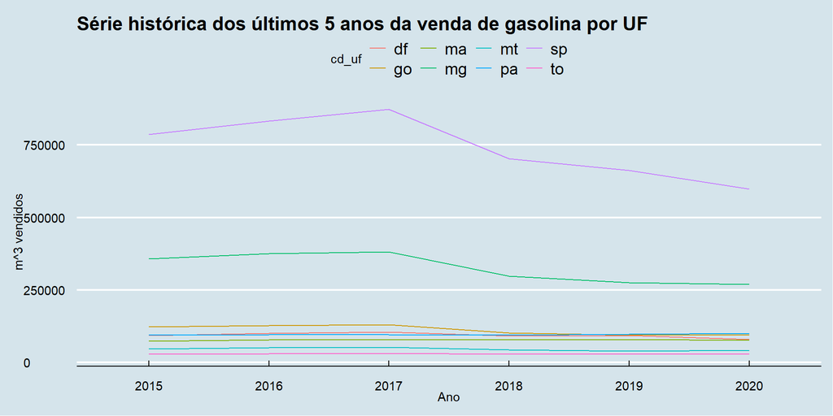

A partir do gráfico se consegue compreender a sazonalidade e a dimensão das vendas de gasolina em cada UF. Primeiramente é importante ressaltar que o mercado com o maior vendas é o paulista, seguido por Minas Gerais. Isso se deve à quantidade de automóveis grande nos dois estados, à sua vasta população, e a alta densidade de indústrias. Quanto à sazonalidade se percebe que ela é similar em todas as UF’s, com crescimento até meados de 2017, decrescimento até 2018 e desaceleração desse descrescimento de 2018 até 2020. Quanto à sazonalidade das vendas de gasolina no Brasil, se encontra um caso similar, como se confere a seguir:

Visualição gráfica da sazonalidade das vendas no mercado de combustível nos últimos 5 ano, para o Brasil.

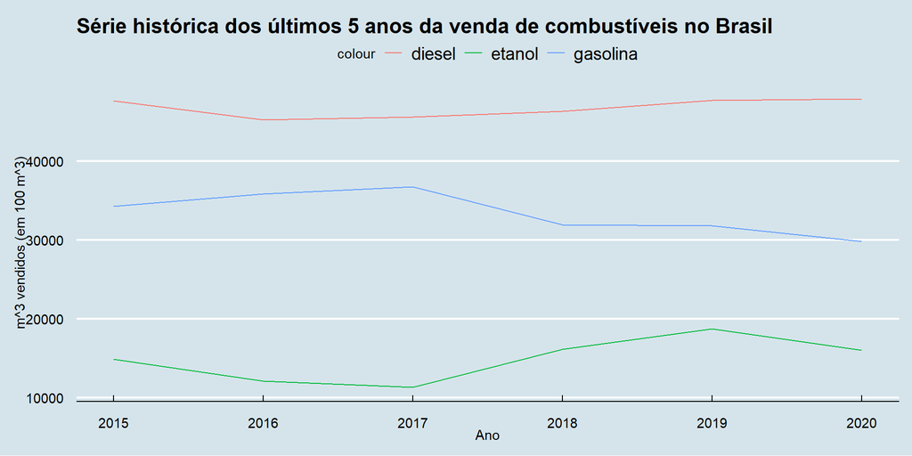